# ECO-MRIO-SFC Model: 54-Sector Version Documentation

## MRIO $A$ Matrix Visualization

Importantly, the column names of the $A$ matrix contained in `identif` determine the country and industry labels in the whole model, following the grammar `country_label.industry_label`:

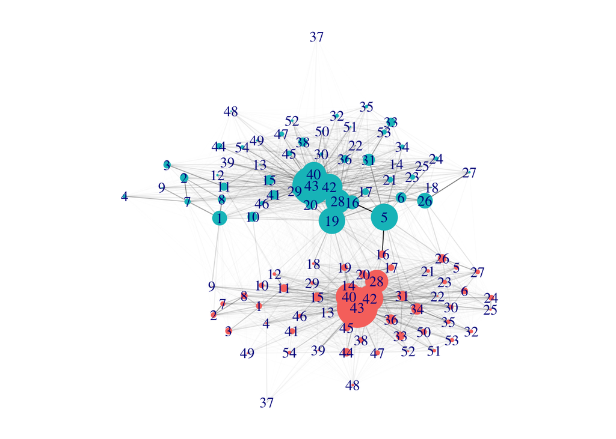

```r
library(igraph)
library(qgraph)
go <- rowSums(initial$A.matrix)
g <- graph_from_adjacency_matrix(as.matrix(initial$A.matrix),
                                 mode = 'directed', weighted = TRUE,diag = F, add.colnames = T)

# Graph Visualization
e <- get.edgelist(g, names=FALSE)
l <- qgraph.layout.fruchtermanreingold(e,vcount=vcount(g))
V(g)$size <- 7.5 * go ^ 0.75
V(g)$frame.color <- NA
# V(g)$name <- apply(expand.grid(1 : unique(initial$K), initial$countries)[c(2,1)], 1, function(x) paste(x, collapse = ""))
V(g)$name <- rep(1 : unique(initial$K), times = 2)
V(g)$color <- rep(scales :: hue_pal()(4)[c(1, 3)], each = unique(initial$K))
E(g)$color <- alpha('black', E(g)$weight / max(E(g)$weight))

par(mar = c(0,0,0,0))
plot(g, edge.arrow.size = 0)
```

```r
# title("MRIO (EU, red; RoW, emerald)")
```

Circular economy matrix $B$ is computed from the $A$ matrix using parameters `more.input` and `less.input` to obtain the new coefficients from the old ones.

# Run New Model Baseline

Function `run.new.model` loads initial values `initial` as first argument and runs the model equations at time period $t$ of the second argument as in `mvp.model` (for instance stored in `MVP_model.R`), in this case using the Gauss-Seidel solver that checks convergence to a stable solution at each iteration:

```r
initial$pars['shock', 'value'] <- 0
#baseline <- run.new.model(initial, mvp.model)
#saveRDS(baseline, paste0(directory, 'data/baseline54_jul31_jbf.RDS'))

baseline <- readRDS(paste0(directory, 'data/baseline54_jul31_jbf.RDS'))
```

For 5 sectors, the old model run globally took ~13 secs, while the new model run globally took ~30 secs. However, run as a function, the old model takes ~1.8 min and the new model takes ~33 secs. For 54 sectors, the new model takes ~5 min.

Model equations are adapted, with some minor changes documented in the file `run.new.model`, from the file `Model_rev (JBF_Revised Feb_with public Investment)_adapted`. Now all industry-level and country-level variables are saved into a single vector `sim`. Parameters (scalars in the old code) are saved into a single vector `para`. In the old code, we could distinguish between demand-led and actual industry-level variables, which is no longer the case (all are actual).

```r
dim(baseline$simulation)
```

```
##          nPeriods
##     5279      100
```

# Example Baseline Visualization

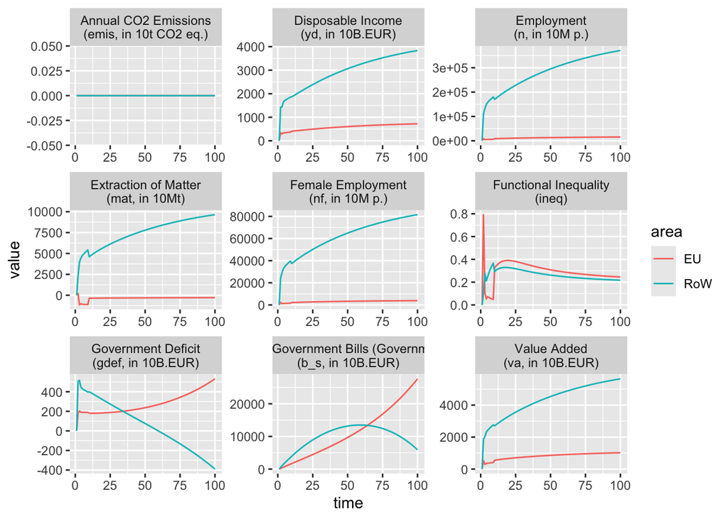

```r
selected <- c('va', 'n', 'nf', 'ineq', 'emis', 'mat', 'gdef', 'b_s', 'yd')

p.selected <- plot.vars(baseline, selected)
```

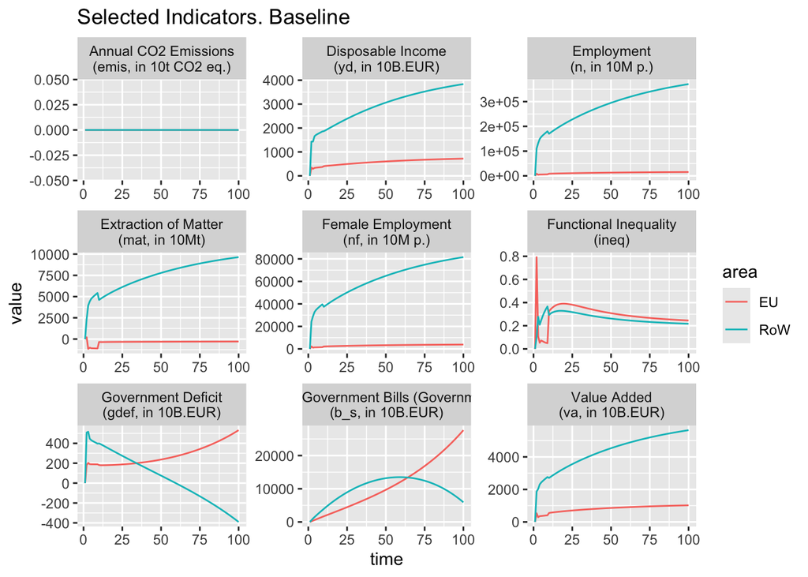

```r
p.selected + ggtitle('Selected Indicators. Baseline')
```

# Calibration

## Load Target Set and Table

Target values are loaded in format long (`target.set`) and wide (`target.table.0`). Units are divided by 10,000 for convenience.

```r
#### LOAD TARGET VALUES ####
target.file <- paste0(directory, 'data/target_values.xlsx')
target.table.0 <- openxlsx :: read.xlsx(target.file, sheet = 'Target', rowNames = TRUE) / 10000
target.set <- data.frame(area = rep(c('Z1', 'Z2'), times = dim(target.table.0)[2]),
                         var.label = rep(c('c', 'id', 'g', 'rex', 'imp', NA, 'M_TOT_int', 'fd', 'va', 'go', 'gdef', NA, NA), each = 2),
                         value = unlist(target.table.0))
target.set$var[!is.na(target.set$var.label)] <- paste0(target.set$area[!is.na(target.set$var.label)], '_', target.set$var[!is.na(target.set$var.label)])
target.set$type <- setNames(variable.table$type, variable.table$label)[target.set$var.label]
target.set$variable <- paste0(setNames(variable.table$name, variable.table$label)[target.set$var.label], '\n(', target.set$var.label, ')')

head(target.set)
```

```
##    area var.label     value   var              type
## C1   Z1         c  626.3179  Z1_c        households
## C2   Z2         c 2370.7060  Z2_c        households
## I1   Z1        id  196.6151 Z1_id        investment
## I2   Z2        id  908.6721 Z2_id        investment
## G1   Z1         g  239.4593  Z1_g govt.central.bank
## G2   Z2         g  675.3284  Z2_g govt.central.bank
##                                  variable
## C1            Total Real Consumption\n(c)
## C2            Total Real Consumption\n(c)
## I1 Real Investment in Fixed Capital\n(id)
## I2 Real Investment in Fixed Capital\n(id)
## G1               Government Spending\n(g)
## G2               Government Spending\n(g)
```

```r
# target.variables <- colnames(target.table.0)
target.variables <- c('GDEF', 'DEBT.GDP', 'BS')
target.indices <- colnames(target.table.0) %in% target.variables
target.table <- target.table.0[ , target.indices]

target.table.0
```

```
##             C        I        G         X         M    X.int    M.int       FD
## EU   626.3179 196.6151 239.4593 102.77593  66.35708 105.8546 123.1518 1098.811
## ROW 2370.7060 908.6721 675.3284  66.35708 102.77593 123.1518 105.8546 3918.288
##          GDP       GO GDEF DEBT.GDP  BS
## EU  1081.514 2153.602 0.01      0.8 100
## ROW 3935.585 8424.517 0.01      0.6 100
```

## Target Values

```r
target.set$target[!is.na(target.set$var)] <- baseline$simulation[target.set$var[!is.na(target.set$var)],
                                                                 baseline$initial$pars['nPeriods', 'value']]
target.set$ratio <- round(target.set$target / target.set$value, 2)

compute.target(baseline)
```

```
## $table
##                C1          C2          I1          I2         G1          G2
## value  626.317880 2370.705952 196.6150852 908.6720956 239.459251 675.3283891
## target 648.589320 3414.873266 107.3256041 777.2068503 240.000000 675.0000000
## ratio    1.035559    1.440446   0.5458666   0.8553216   1.002258   0.9995137
##                  X1         X2         M1           M2   X.int1   X.int2
## value  102.77593069 66.3570804 66.3570804 102.77593069 105.8546 123.1518
## target   2.24272581 31.7018926 31.7018926   2.24272581       NA       NA
## ratio    0.02182151  0.4777469  0.4777469   0.02182151       NA       NA
##             M.int1     M.int2          FD1         FD2         GDP1        GDP2
## value  123.1518166 105.854567 1098.8110660 3918.287587 1081.5138161 3935.584836
## target  89.5123512 127.159396  904.4672329 5238.527808 1022.3858988 5643.800604
## ratio    0.7268456   1.201265    0.8231326    1.336943    0.9453286    1.434044
##                 GO1          GO2      GDEF1       GDEF2 DEBT.GDP1 DEBT.GDP2 BS1
## value  2153.6024940  8424.517003     0.0100      0.0100       0.8       0.6 100
## target 1720.9022470 10416.366390   532.1086   -390.3847        NA        NA  NA
## ratio     0.7990807     1.236435 53210.8593 -39038.4710        NA        NA  NA
##        BS2
## value  100
## target  NA
## ratio   NA
##
## $fitness
## [1] 217768471
```

## GDEF Components

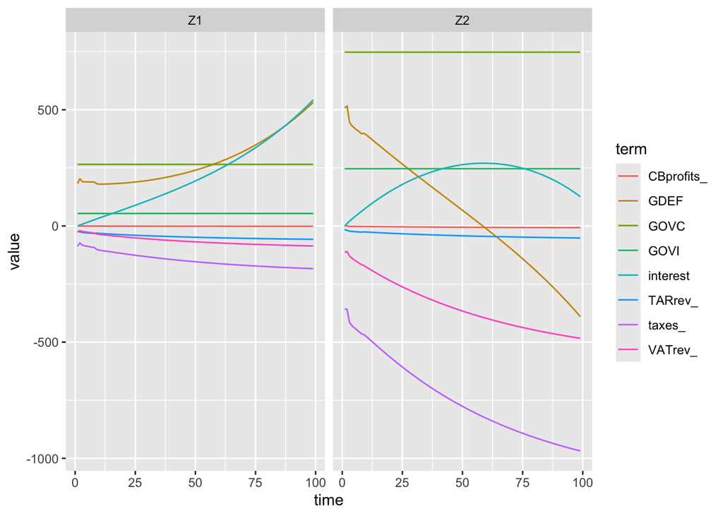

```r
sim <- baseline$simulation
i <- 2 : baseline$initial$pars['nPeriods', 'value']
gdef.terms <- list(GDEF = sim[z.lab('gdef'), i],
                   GOVC = sim[z.lab('g'), i] * sim[z.lab('pg'), i],
                   taxes_ = - sim[z.lab('t'), i],
                   interest = sim[z.lab('rb'), i-1] * sim[z.lab('b_s'), i-1],
                   CBprofits_ = - sim[z.lab('f_cb'), i],
                   VATrev_ = - sim[z.lab('vat_rev'), i],
                   TARrev_ = - sim[z.lab('tar_rev'), i],
                   GOVI = sim[z.lab('id_g'), i] * sim[z.lab('pid'), i]) %>% lapply(t) %>% data.frame %>% t

df <- melt(gdef.terms) %>% rename(variable = Var1, time = Var2)
df$area <- stringr :: str_extract(df$variable, "Z[0-9]+")
df$term <- sapply(strsplit(as.character(df$variable), split = '.', fixed = T), function (x) x[[1]])

df %>% ggplot(aes(x = time, y = value, color = term)) + geom_line() + facet_grid(~ area)
```

## Select Instrument Variables

We select instrument variables:

```r
instruments <- list(var.ind = c('kappa', 'vat', 'tar'),
                    var.agg = c('theta_w', 'theta_c', 'mu_b', 'r_star'),
                    par = c('alpha1', 'alpha2', 'alpha3', 'gamma', 'delta', 'mu0', 'mu1', 'mu2'))
```

## Random Search Algorithm

And start the random search algorithm that minimizes the goodness-of-fit (not run, but saved).

```r
std.dev <- .1
results <- baseline # initial run
universe <- list() # universe is a list that saves each run of the model for each of its elements
universe[[1]] <- list(initial = results$initial,
                      instruments = return.instr.vals(results),# instrument values
                      simulation = results$simulation,         # simulation values
                      target = compute.target(results)$table, # values of target variables
                      fitness = compute.target(results)$fitness)  # fitness value (a sum of the ratios - 1)

# WHILE LOOP
iters <- k <- 1
print('ITERATIONS  SUCCESSFUL.RUNS   CURRENT.FITNESS  RUN.FITNESS   DIFFERENCE')
print(c(iters, k, universe[[k]]$fitness))
while (iters < 70)
{
  # Adjust Parameters and Run Model
  sim <- universe[[k]]$initial

  sim$vars[sapply(instruments$var.agg, z.lab) %>% as.vector, 'value'] <- rnorm(N * length(instruments$var.agg), 1, std.dev) * sim$vars[sapply(instruments$var.agg, z.lab) %>% as.vector, 'value']
  sim$vars[sapply(instruments$var.ind, zk.lab) %>% as.vector, 'value'] <- rep(rnorm(N * length(instruments$var.ind), 1, std.dev) * as.vector(sapply(instruments$var.ind, function (x) zk.mean(sim$vars[zk.lab(x), 'value']))), each = unique(K))
  sim$pars[sapply(instruments$par, z.lab) %>% as.vector, 'value'] <- rnorm(N * length(instruments$par), 1, std.dev) * sim$pars[sapply(instruments$par, z.lab) %>% as.vector, 'value']

  # Boundary Conditions so Parameters are Meaningful
  if(sim$pars['Z1_alpha1', 'value'] > 1) sim$pars['Z1_alpha1', 'value'] <- .99
  if(sim$pars['Z1_alpha2', 'value'] > 1) sim$pars['Z1_alpha2', 'value'] <- .99
  if(sim$pars['Z1_alpha3', 'value'] > 1) sim$pars['Z1_alpha3', 'value'] <- .99

  if(sim$pars['Z2_alpha1', 'value'] > 1) sim$pars['Z2_alpha1', 'value'] <- .99
  if(sim$pars['Z2_alpha2', 'value'] > 1) sim$pars['Z2_alpha2', 'value'] <- .99
  if(sim$pars['Z2_alpha3', 'value'] > 1) sim$pars['Z2_alpha3', 'value'] <- .99

  if(sim$pars['Z1_alpha2', 'value'] > sim$pars['Z1_alpha1', 'value']) sim$pars['Z1_alpha2', 'value'] <- sim$parameters['Z1_alpha1', 'value']
  if(sim$pars['Z1_alpha3', 'value'] > sim$pars['Z1_alpha2', 'value']) sim$pars['Z1_alpha3', 'value'] <- sim$parameters['Z1_alpha2', 'value']

  if(sim$pars['Z2_alpha2', 'value'] > sim$pars['Z2_alpha1', 'value']) sim$pars['Z2_alpha2', 'value'] <- sim$pars['Z2_alpha1', 'value']
  if(sim$pars['Z2_alpha3', 'value'] > sim$pars['Z2_alpha2', 'value']) sim$pars['Z2_alpha3', 'value'] <- sim$pars['Z2_alpha2', 'value']

  results <- run.new.model(sim, mvp.model)

  # If New Fitness is Lower, Save Parameters
  if (universe[[k]]$fitness > compute.target(results)$fitness)
  {
    # if (abs(results$simulation$variables['Z1_gdef', 75]) < 10 & abs(results$simulation$variables['Z2_gdef', 75]) < 10)
    # {
      k <- k + 1
      universe[[k]] <- list(initial = results$initial,
                      instruments = return.instr.vals(results),# instrument values
                      simulation = results$simulation,         # simulation values
                      target = compute.target(results)$table, # values of target variables
                      fitness = compute.target(results)$fitness)  # fitness value (a sum of the ratios - 1)
#    }
  }
  print(c(iters <- iters + 1, k, universe[[k]]$fitness, results$fitness, universe[[k]]$fitness - results$fitness))
}
universe[[k]]$target
# saveRDS(universe, file = 'data/universe_jul31.RDS')
```